# Regression

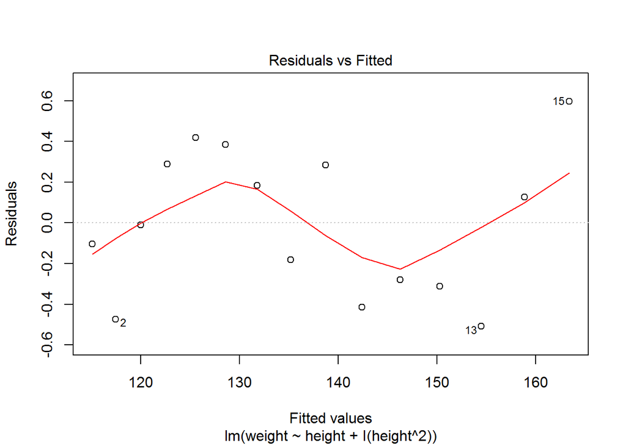

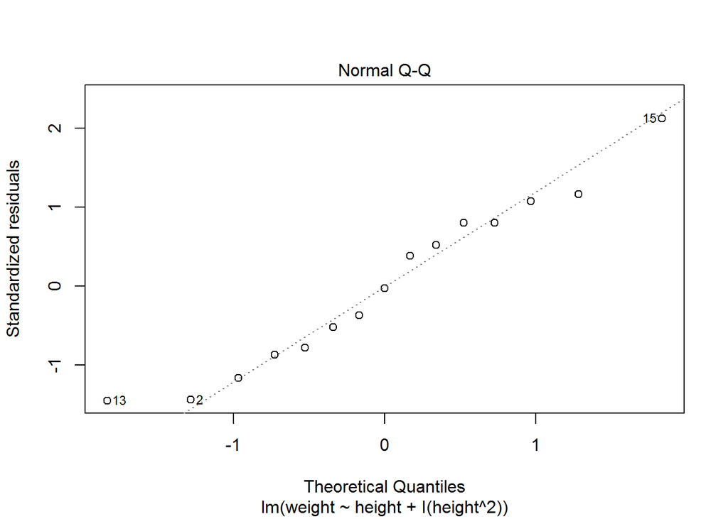

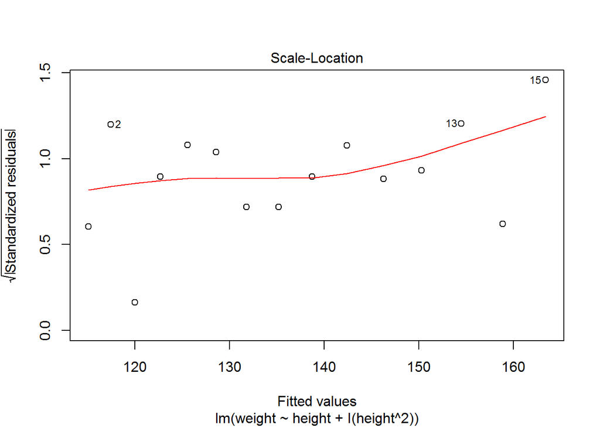

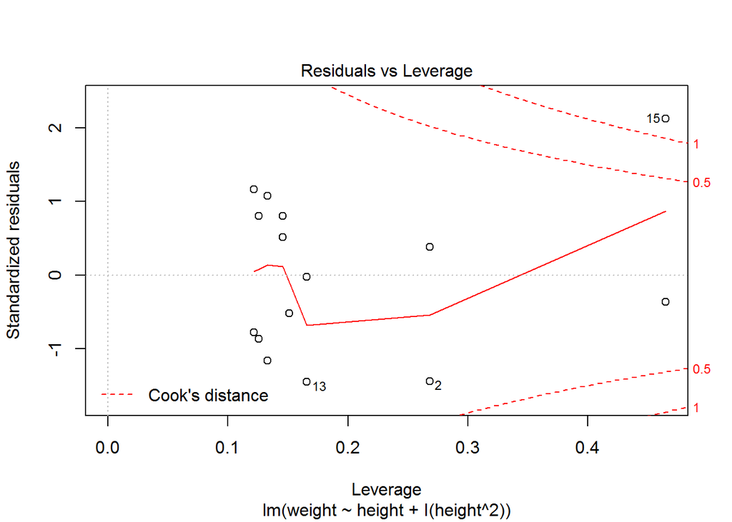

```r
#加入平方项回归
fit2 <- lm(weight ~ height + I(height^2), data=women)
plot(fit2)
```

## 1.6 系数之间相关影响实验

In order to explain the meaning of coefficients ,we have the following step.
Regression model:
$$y_i=\beta_0+\beta_1x_{i1}+\beta_2x_{i2}+u_i$$
Step 1:
$$w_i=y_i-\hat{\alpha}_0-\hat{\alpha}_1x_{i2}$$
Step 2:
$$v_i=x_{i1}-\hat{b}_0-\hat{b}_1x_{i2}$$
Step 3:
$$\bar{\beta}_1=\frac{\sum v_iw_i}{\sum v_i^{2}}$$

```r
mtcar <- as.data.frame(mtcars[,c("mpg", "cyl", "disp", "hp", "wt")])
fit <- lm(mpg~wt+disp, data=mtcar)
summary(fit)
```

```
##
## Call:
## lm(formula = mpg ~ wt + disp, data = mtcar)
##
## Residuals:
##    Min     1Q Median     3Q    Max
## -3.409 -2.324 -0.768  1.772  6.348
##
## Coefficients:
##             Estimate Std. Error t value Pr(>|t|)
## (Intercept) 34.96055    2.16454   16.15  4.9e-16 ***
## wt          -3.35083    1.16413   -2.88   0.0074 **
## disp        -0.01772    0.00919   -1.93   0.0636 .
## ---
## Signif. codes:  0 '***' 0.001 '**' 0.01 '*' 0.05 '.' 0.1 ' ' 1
##
## Residual standard error: 2.92 on 29 degrees of freedom
## Multiple R-squared:  0.781,  Adjusted R-squared:  0.766
## F-statistic: 51.7 on 2 and 29 DF,  p-value: 2.74e-10
```

```r
fit1 <- lm(mpg~disp, data=mtcar)
fit2 <- lm(wt~disp, data=mtcar)
fit3 <- lm(fit1$residuals~fit2$residuals-1)#没常数项用-1
summary(fit3)
```

```
##
## Call:
## lm(formula = fit1$residuals ~ fit2$residuals - 1)
##
## Residuals:
##    Min     1Q Median     3Q    Max
## -3.409 -2.324 -0.768  1.772  6.348
##
## Coefficients:
##                Estimate Std. Error t value Pr(>|t|)
## fit2$residuals    -3.35       1.13   -2.98   0.0056 **
## ---
## Signif. codes:  0 '***' 0.001 '**' 0.01 '*' 0.05 '.' 0.1 ' ' 1
##
## Residual standard error: 2.82 on 31 degrees of freedom
## Multiple R-squared:  0.222,  Adjusted R-squared:  0.197
## F-statistic: 8.86 on 1 and 31 DF,  p-value: 0.00562
```

说明x2对x1系数没有影响

## 1.7 置信区间

```r
mtcar <- as.data.frame(mtcars[,c("mpg", "cyl", "disp", "hp", "wt")])
mtcarn<-mtcar[order(mtcar$wt),]
fit <- lm(mpg~wt, data=mtcarn)
conf=predict(fit,interval="confidence",level=0.95)
conf
```

```
##                       fit   lwr  upr
## Lotus Europa        29.20 26.96 31.4
## Honda Civic         28.65 26.52 30.8
## Toyota Corolla      27.48 25.55 29.4
## Fiat X1-9           26.94 25.11 28.8
## Porsche 914-2       25.85 24.20 27.5
## Fiat 128            25.53 23.93 27.1
## Datsun 710          24.89 23.38 26.4
## Toyota Corona       24.11 22.72 25.5
## Mazda RX4           23.28 21.99 24.6
## Ferrari Dino        22.48 21.27 23.7
## Volvo 142E          22.43 21.22 23.6
## Mazda RX4 Wag       21.92 20.75 23.1
## Merc 230            20.45 19.35 21.6
## Ford Pantera L      20.34 19.24 21.4
## Merc 240D           20.24 19.14 21.3
## Hornet 4 Drive      20.10 19.00 21.2
## AMC Javelin         18.93 17.80 20.1
## Hornet Sportabout   18.90 17.77 20.0
## Merc 280            18.90 17.77 20.0
## Merc 280C           18.90 17.77 20.0
## Valiant             18.79 17.66 19.9
## Dodge Challenger    18.47 17.32 19.6
## Duster 360          18.21 17.03 19.4
## Maserati Bora       18.21 17.03 19.4
## Merc 450SL          17.35 16.10 18.6
## Merc 450SLC         17.08 15.81 18.4
## Camaro Z28          16.76 15.45 18.1
## Pontiac Firebird    16.74 15.42 18.0
## Merc 450SE          15.53 14.06 17.0
## Cadillac Fleetwood   9.23  6.66 11.8
## Chrysler Imperial    8.72  6.05 11.4
## Lincoln Continental  8.30  5.55 11.0
```

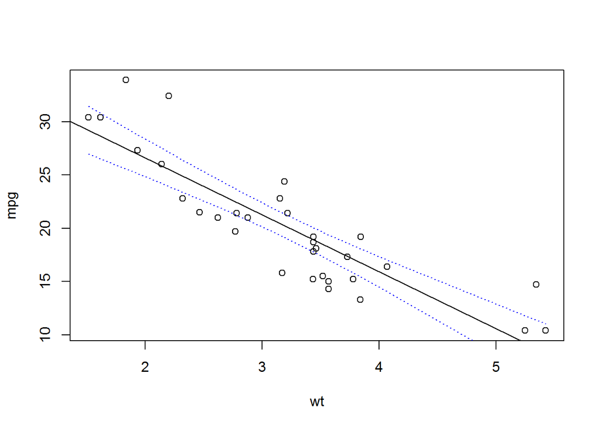

```r
plot(mpg~wt, data=mtcarn)
abline(fit)
lines(mtcarn$wt,conf[,2],lty=3,col="blue")
lines(mtcarn$wt,conf[,3],lty=3,col="blue")
```

## 1.8 假设检验

```r
mtcar <- as.data.frame(mtcars[,c("mpg", "cyl",
"disp", "hp", "wt")])
library(car)
fit <- lm(mpg ~ hp + wt, data = mtcar)
summary(fit)
```

```
##
## Call:
## lm(formula = mpg ~ hp + wt, data = mtcar)
##
## Residuals:
##    Min     1Q Median     3Q    Max
## -3.941 -1.600 -0.182  1.050  5.854
##
## Coefficients:
##             Estimate Std. Error t value Pr(>|t|)
## (Intercept) 37.22727    1.59879   23.28  < 2e-16 ***
## hp          -0.03177    0.00903   -3.52   0.0015 **
## wt          -3.87783    0.63273   -6.13  1.1e-06 ***
## ---
## Signif. codes:  0 '***' 0.001 '**' 0.01 '*' 0.05 '.' 0.1 ' ' 1
##
## Residual standard error: 2.59 on 29 degrees of freedom
## Multiple R-squared:  0.827,  Adjusted R-squared:  0.815
## F-statistic: 69.2 on 2 and 29 DF,  p-value: 9.11e-12
```

```r
linearHypothesis(fit, "hp = 0")#变量hp的系数=0
```

```
## Linear hypothesis test
##
## Hypothesis:
## hp = 0
##
## Model 1: restricted model
## Model 2: mpg ~ hp + wt
##
##   Res.Df RSS Df Sum of Sq    F Pr(>F)
## 1     30 278
## 2     29 195  1      83.3 12.4 0.0015 **
## ---
## Signif. codes:  0 '***' 0.001 '**' 0.01 '*' 0.05 '.' 0.1 ' ' 1
```

```r
linearHypothesis(fit, "hp = -0.5")
```

```
## Linear hypothesis test
##
## Hypothesis:
## hp = - 0.5
##
## Model 1: restricted model
## Model 2: mpg ~ hp + wt
##
##   Res.Df   RSS Df Sum of Sq    F Pr(>F)
## 1     30 18280
## 2     29   195  1     18085 2689 <2e-16 ***
## ---
## Signif. codes:  0 '***' 0.001 '**' 0.01 '*' 0.05 '.' 0.1 ' ' 1
```

```r
linearHypothesis(fit, "hp - wt= 0")#hp和wt相等
```

```
## Linear hypothesis test
##
## Hypothesis:
## hp - wt = 0
##
## Model 1: restricted model
## Model 2: mpg ~ hp + wt
##
##   Res.Df RSS Df Sum of Sq    F  Pr(>F)
## 1     30 439
## 2     29 195  1       244 36.3 1.5e-06 ***
## ---
## Signif. codes:  0 '***' 0.001 '**' 0.01 '*' 0.05 '.' 0.1 ' ' 1
```

F检验的f值，总是对应假设中T检验t值的平方（要在相同原假设下采用正确形式）

## 1.9 虚拟变量（Dummy）

例如：是否要加入异常值、季节调整、经济结构改变（名义变量）  
dummy variable 的取值是0和1  
- coincident regression ：2个方程截距和斜率都相等  
- parallel regression：2个方程仅截距项不同  
- concurrent regression：2个方程仅斜率不同  
- dissimilar regression：2个方程斜率和截距项都不同

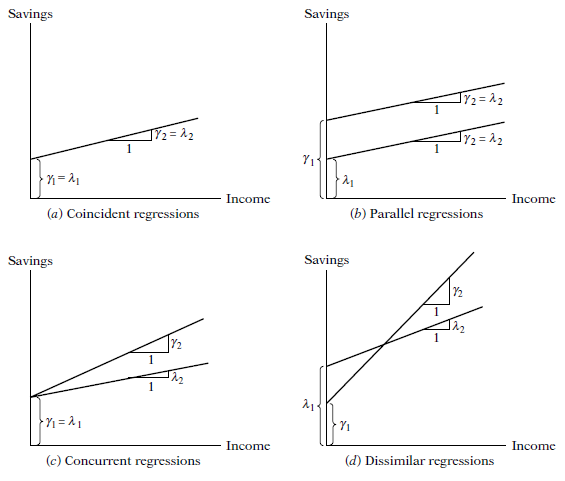

如果只有一个虚拟变量就直接加入方程回归
有多个状态（lebvel）的时候要建立多个虚拟变量
例如3个状态（is Asian？）（is Caucasian？）（is African Americ？）
需要2个随机变量
$$D_{i1} = \left\{
\begin{array}{ll}
1 & \textrm{if ith person is Asian}\\
0 & \textrm{if ith person is not Asian}\\
\end{array}
\right.$$
and
$$D_{i2} = \left\{
\begin{array}{ll}
1 & \textrm{if ith person is Caucasian}\\
0 & \textrm{if ith person is not Caucasian}\\
\end{array}
\right.$$
回归模型为：
$$y_i=\beta_0+\beta_1D_{i1}+\beta_2D_{i2}+\epsilon_i=
\left\{
\begin{array}{ll}
\beta_0+\beta_1+\epsilon_i & \textrm{if ith person is Asian} \\
\beta_0+\beta_2+\epsilon_i & \textrm{if ith person is Caucasian} \\
\beta_0+\epsilon_i & \textrm{if ith person is African Americ} \\
\end{array}
\right.$$
此时$\beta_0$ 是African Americ的基准水平，$\beta_1$ 是Asian和African Americ之间基准水平的差距，$\beta_2$ 是Caucasian和African Americ之间基准水平的差距
其中African Americ叫基准类（baseline：不含$\beta_1$ 和$\beta_2$）
3个level只要2个虚拟变量，加了3个会有完全共线性

```r
#导入消费数据
con_China<-read.csv("C:\\Users\\44180\\Documents\\R-in-SOE\\R\\R-class\\c9\\consumption_China.csv")
names(con_China)<-c("year","c","y")
names(con_China)
```

```
## [1] "year" "c"    "y"
```

```r
#判别>=1992为true，小于的false
Dummy<-con_China$year>=1992
Dummy
```

```
##  [1] FALSE FALSE FALSE FALSE FALSE FALSE FALSE FALSE FALSE FALSE FALSE
## [12] FALSE FALSE FALSE  TRUE  TRUE  TRUE  TRUE  TRUE  TRUE  TRUE  TRUE
## [23]  TRUE  TRUE  TRUE  TRUE  TRUE  TRUE  TRUE
```

```r
#改变成0-1
Dummy<-as.numeric(Dummy)
Dummy
```

```
##  [1] 0 0 0 0 0 0 0 0 0 0 0 0 0 0 1 1 1 1 1 1 1 1 1 1 1 1 1 1 1
```

```r
#导入工资数据
wage1<-read.csv("C:\\Users\\44180\\Documents\\R-in-SOE\\R\\R-class\\c9\\wage1.csv",header=T)
head(wage1)
```

```
##   wage educ exper tenure nonwhite female married numdep smsa northcen
## 1 3.10   11     2      0        0      1       0      2    1        0
## 2 3.24   12    22      2        0      1       1      3    1        0
## 3 3.00   11     2      0        0      0       0      2    0        0
## 4 6.00    8    44     28        0      0       1      0    1        0
## 5 5.30   12     7      2        0      0       1      1    0        0
## 6 8.75   16     9      8        0      0       1      0    1        0
##   south west construc ndurman trcommpu trade services profserv profocc
## 1     0    1        0       0        0     0        0        0       0
## 2     0    1        0       0        0     0        1        0       0
## 3     0    1        0       0        0     1        0        0       0
## 4     0    1        0       0        0     0        0        0       0
## 5     0    1        0       0        0     0        0        0       0
## 6     0    1        0       0        0     0        0        1       1
##   clerocc servocc lwage expersq tenursq
## 1       0       0  1.13       4       0
## 2       0       1  1.18     484       4
## 3       0       0  1.10       4       0
## 4       1       0  1.79    1936     784
## 5       0       0  1.67      49       4
## 6       0       0  2.17      81      64
```

```r
#回归0。结果带星号显著
lm.wage<-lm(lwage~ female+educ+exper+expersq+tenure+tenursq,data=wage1)
summary(lm.wage)
```

```
##
## Call:
## lm(formula = lwage ~ female + educ + exper + expersq + tenure +
##     tenursq, data = wage1)
##
## Residuals:
##     Min      1Q  Median      3Q     Max
## -1.8316 -0.2566 -0.0213  0.2550  1.1337
##
## Coefficients:
##              Estimate Std. Error t value Pr(>|t|)
## (Intercept)  0.416691   0.098928    4.21  3.0e-05 ***
## female      -0.296511   0.035805   -8.28  1.0e-15 ***
## educ         0.080197   0.006757   11.87  < 2e-16 ***
## exper        0.029432   0.004975    5.92  6.0e-09 ***
## expersq     -0.000583   0.000107   -5.43  8.6e-08 ***
## tenure       0.031714   0.006845    4.63  4.6e-06 ***
## tenursq     -0.000585   0.000235   -2.49    0.013 *
## ---
## Signif. codes:  0 '***' 0.001 '**' 0.01 '*' 0.05 '.' 0.1 ' ' 1
##
## Residual standard error: 0.4 on 519 degrees of freedom
## Multiple R-squared:  0.441,  Adjusted R-squared:  0.434
## F-statistic: 68.2 on 6 and 519 DF,  p-value: <2e-16
```

```r
#生成4个虚拟变量，结婚|男女
attach(wage1)
marrmale<-as.numeric(married==1 & female==0)
marrfemale<-as.numeric(married==1 & female==1)
singmale<-as.numeric(married==0 & female==0)
singfem<-as.numeric(married==0 & female==1)
#只放3个虚拟变量进入回归1
lm.wage1<-lm(lwage~marrmale+marrfemale+singfem+educ+exper+tenure+expersq+tenursq)
summary(lm.wage1)
```

```
##
## Call:
## lm(formula = lwage ~ marrmale + marrfemale + singfem + educ +
##     exper + tenure + expersq + tenursq)
##
## Residuals:
##     Min      1Q  Median      3Q     Max
## -1.8970 -0.2406 -0.0269  0.2314  1.0920
##
## Coefficients:
##              Estimate Std. Error t value Pr(>|t|)
## (Intercept)  0.321378   0.100009    3.21  0.00139 **
## marrmale     0.212676   0.055357    3.84  0.00014 ***
## marrfemale  -0.198268   0.057835   -3.43  0.00066 ***
## singfem     -0.110350   0.055742   -1.98  0.04827 *
## educ         0.078910   0.006694   11.79  < 2e-16 ***
## exper        0.026801   0.005243    5.11  4.5e-07 ***
## tenure       0.029088   0.006762    4.30  2.0e-05 ***
## expersq     -0.000535   0.000110   -4.85  1.7e-06 ***
## tenursq     -0.000533   0.000231   -2.31  0.02153 *
## ---
## Signif. codes:  0 '***' 0.001 '**' 0.01 '*' 0.05 '.' 0.1 ' ' 1
##
## Residual standard error: 0.393 on 517 degrees of freedom
## Multiple R-squared:  0.461,  Adjusted R-squared:  0.453
## F-statistic: 55.2 on 8 and 517 DF,  p-value: <2e-16
```

```r
#放入全部4个level，最后一个加入的虚拟变量系统默认全为NA无法计算（因为完全多重共线性）
lm.wage2<-lm(lwage~marrmale+marrfemale+singfem+educ+exper+tenure+expersq+tenursq+singmale)
summary(lm.wage2)
```

```
##
## Call:
## lm(formula = lwage ~ marrmale + marrfemale + singfem + educ +
##     exper + tenure + expersq + tenursq + singmale)
##
## Residuals:
##     Min      1Q  Median      3Q     Max
## -1.8970 -0.2406 -0.0269  0.2314  1.0920
##
## Coefficients: (1 not defined because of singularities)
##              Estimate Std. Error t value Pr(>|t|)
## (Intercept)  0.321378   0.100009    3.21  0.00139 **
## marrmale     0.212676   0.055357    3.84  0.00014 ***
## marrfemale  -0.198268   0.057835   -3.43  0.00066 ***
## singfem     -0.110350   0.055742   -1.98  0.04827 *
## educ         0.078910   0.006694   11.79  < 2e-16 ***
## exper        0.026801   0.005243    5.11  4.5e-07 ***
## tenure       0.029088   0.006762    4.30  2.0e-05 ***
## expersq     -0.000535   0.000110   -4.85  1.7e-06 ***
## tenursq     -0.000533   0.000231   -2.31  0.02153 *
## singmale           NA         NA      NA       NA
## ---
## Signif. codes:  0 '***' 0.001 '**' 0.01 '*' 0.05 '.' 0.1 ' ' 1
##
## Residual standard error: 0.393 on 517 degrees of freedom
## Multiple R-squared:  0.461,  Adjusted R-squared:  0.453
## F-statistic: 55.2 on 8 and 517 DF,  p-value: <2e-16
```

```r
#baseline:单身男性，则已婚男性的截距为系数married 0.2126756+截距项0.3213780
fema<-female*married
lm.wage3<-lm(lwage~female+married+fema+educ+exper+tenure+expersq+tenursq)
summary(lm.wage3)
```

```
##
## Call:
## lm(formula = lwage ~ female + married + fema + educ + exper +
##     tenure + expersq + tenursq)
##
## Residuals:
##     Min      1Q  Median      3Q     Max
## -1.8970 -0.2406 -0.0269  0.2314  1.0920
##
## Coefficients:
##              Estimate Std. Error t value Pr(>|t|)
## (Intercept)  0.321378   0.100009    3.21  0.00139 **
## female      -0.110350   0.055742   -1.98  0.04827 *
## married      0.212676   0.055357    3.84  0.00014 ***
## fema        -0.300593   0.071767   -4.19  3.3e-05 ***
## educ         0.078910   0.006694   11.79  < 2e-16 ***
## exper        0.026801   0.005243    5.11  4.5e-07 ***
## tenure       0.029088   0.006762    4.30  2.0e-05 ***
## expersq     -0.000535   0.000110   -4.85  1.7e-06 ***
## tenursq     -0.000533   0.000231   -2.31  0.02153 *
## ---
## Signif. codes:  0 '***' 0.001 '**' 0.01 '*' 0.05 '.' 0.1 ' ' 1
##
## Residual standard error: 0.393 on 517 degrees of freedom
## Multiple R-squared:  0.461,  Adjusted R-squared:  0.453
## F-statistic: 55.2 on 8 and 517 DF,  p-value: <2e-16
```

```r
detach(wage1)
```

## 1.10 chow test

检验2个不同数据集的线性回归模型中的系数是否equal(相当于是否存在结构变化)
原假设:不存在结构变化
1. 用$n=n_1+n_2$总样本进行回归,得到within group sum of squares :$S_1$,自由度为$n_1+n_2-k$,看是参数个数(包括截距项)
2. 在$n_1$和$n_2$ 2个分样本进行回归得到2个回归方程和2个within group sums of square $S_2+S_3$,自由度$n_1+n_2-2k$
3.
$$F_{k,n_1+n_2-2k} = \frac{[S_1-(S_2+S_3)]/k}{[(S_2+S_3)/(n_1+n_2-2k)]}$$

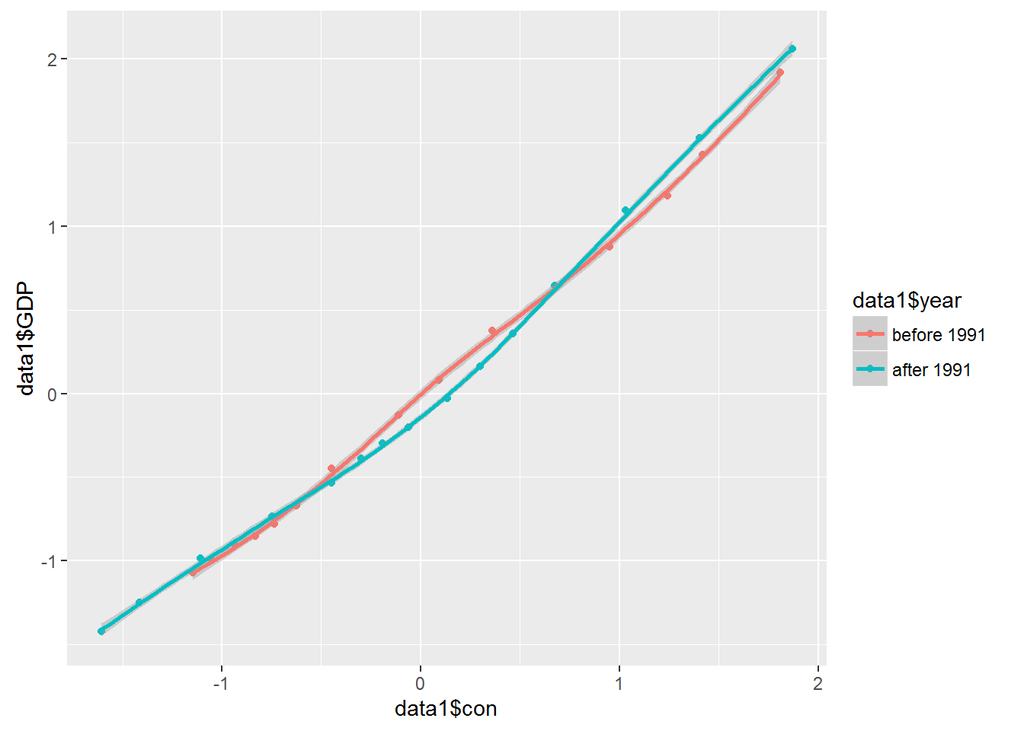

```r
source("C:\\Users\\44180\\Documents\\R-in-SOE\\R\\R-class\\c9\\Chow_test.R")
con_China<-read.csv("C:\\Users\\44180\\Documents\\R-in-SOE\\R\\R-class\\c9\\consumption_China.csv")
#View(con_China)
names(con_China)<-c("year","con","GDP")
attach(con_China)
library("ggplot2")
#分离数据
con1<-con[year<=1991]
con2<-con[year>1991]
GDP1<-GDP[year<=1991]
GDP2<-GDP[year>1991]
#标准化
zGDP1=scale(GDP1, center=TRUE, scale=TRUE)[1:14,1]
zcon1=scale(con1, center=TRUE, scale=TRUE)[1:14,1]
zGDP2=scale(GDP2, center=TRUE, scale=TRUE)[1:15,1]
zcon2=scale(con2, center=TRUE, scale=TRUE)[1:15,1]
#合并
n1 <- length(GDP1)
n2 <- length(GDP2)
y1=rep(0,n1)
y2=rep(1,n2)
dat11<-cbind(zGDP1,zcon1,y1)
dat12<-cbind(zGDP2,zcon2,y2)
data1 <- rbind(dat11,dat12)
data1 <- as.data.frame(data1)
names(data1) <- c("GDP","con","year")
#因子化
data1$year <- factor(data1$year,labels =c("before 1991","after 1991"))
#绘图
p <- ggplot(data = data1,aes(x=data1$con,y=data1$GDP))
p+geom_point(aes(color=data1$year))+stat_smooth(aes(color=data1$year))
```

```r
#chow检验
dat1<-cbind(GDP1,con1)
dat2<-cbind(GDP2,con2)
chow(dat1,dat2)
```

```
##
##  Chow TEST
##
## data:  dat1 and dat2
## F = 10, df1 = 2, df2 = 20, p-value = 1e-04
```

```r
detach(con_China)
#P值很小，拒绝经济结构没有发生改变的原假设
```

## 1.11 正态性检验

tips:数据量大的时候$\alpha$ 最好定小一些  
大数据量：120以上，这个时候其实基本上渐进正态了，此时$\alpha$ 定1%比较好

### 1.11.1 QQ图,Shapiro-Wilk normality test

quantile-quantile plot:比较排序过的样本数据(纵轴)和排序过的正态数据(横轴),如果满足正态性那么样本数据应该在45°线(qq线)附近 Shapiro-Wilk normality test:原假设为满足正态性

```r
# Shapiro-Wilk normality test
y <- rnorm(5000)
#Shapiro-Wilk normality test:p很大,无法拒绝原假设
shapiro.test(y)
```

```
##
##  Shapiro-Wilk normality test
##
## data:  y
## W = 1, p-value = 0.4
```

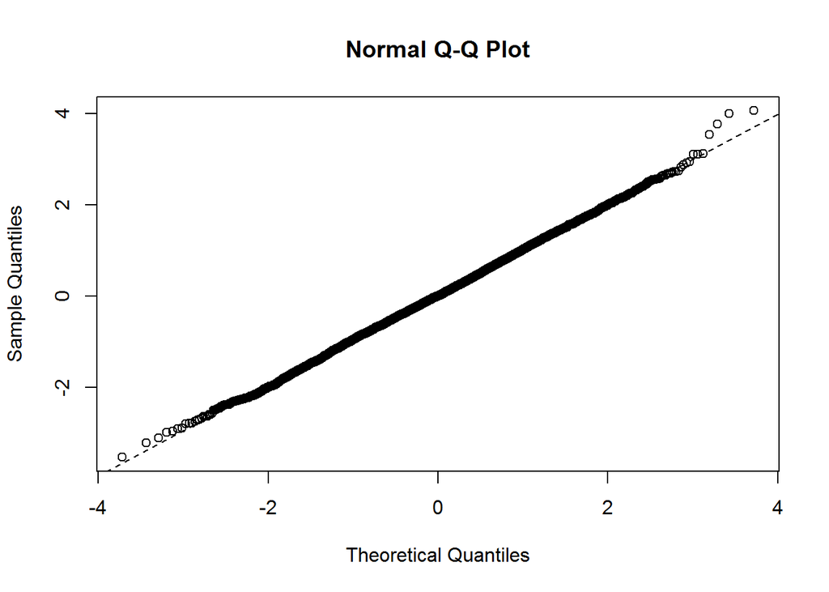

```r
#QQ图
qqnorm(y)
#QQ线
qqline(y,lty=2)
```

```r
#Shapiro-Wilk normality test:p很小,拒绝原假设
shapiro.test(runif(100,min=2,max=4))
```

```
##
##  Shapiro-Wilk normality test
##
## data:  runif(100, min = 2, max = 4)
## W = 0.9, p-value = 2e-04
```

### 1.11.2 正态性检验函数:residplot(自编) car::qqplot

residplot():画出拟合模型的studentized residual密度函数(红虚线)与密度直方图(默认nbreaks=10),并画出正态密度函数(蓝实线)用来对比  
qqplot():横轴:排序后的t分布生成数,纵轴:样本studentized residuals,并给出置信区间

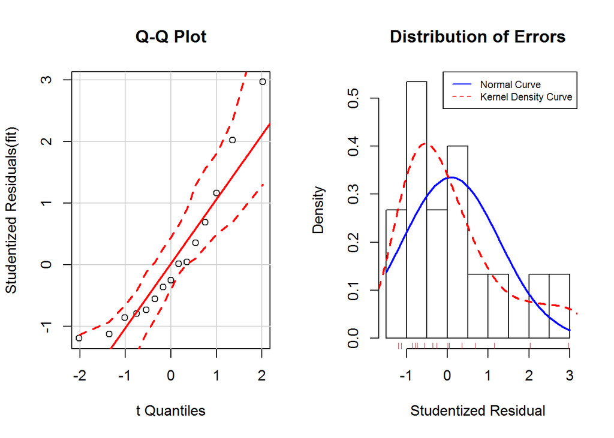

```r
# qqplot residplot
library(car)
fit <- lm(weight ~ height, data=women)
residplot <- function(fit, nbreaks=10) {
z <- rstudent(fit)
hist(z, breaks=nbreaks, freq=FALSE,
xlab="Studentized Residual",
main="Distribution of Errors")
rug(jitter(z), col="brown")
curve(dnorm(x, mean=mean(z), sd=sd(z)),
add=TRUE, col="blue", lwd=2)
lines(density(z)$x, density(z)$y,
col="red", lwd=2, lty=2)
legend("topright",
legend = c( "Normal Curve", "Kernel Density Curve"),
lty=1:2, col=c("blue","red"), cex=.7) }
par(mfrow=c(1,2))
qqPlot(fit,labels=row.names(women),id.method="identify", simulate=TRUE, main="Q-Q Plot")
residplot(fit)
```

### 1.11.3 Jarque–Bera (JB) Test of Normality

- 渐近大样本检验
- 基于OLS residual
- S:skewness of OLS residuals,K:kurtosis of OLS residuals,n:样本容量
- $$JB=n[\frac{S^{2}}{6}+\frac{(K-3)^{2}}{24}]$$
- 正态分布的S=0,K=3,JB检验相当于对联合假设:S=0,K=3进行检验
- 原假设:residuals服从正态分布,此时JB期望为0
- 原假设下JB统计量渐近服从卡方分布(2自由度)

```r
library("ccgarch")
jb.test(fit$residuals)
```

```
##           series 1
## test stat    1.660
## p-value      0.436
```

## 1.12 非线性回归

### 1.12.1 可对数转换

总共有  
1. 线性-线性模型 2. log-log模型，两边都是对数。系数表示x变化1%，y变化的百分比(弹性)

```r
cobb<-read.csv("C:\\Users\\44180\\Documents\\R-in-SOE\\R\\R-class\\c9\\Cobb.csv",header=T)
cobb
```

```
##     obs     Y    X3  X2
## 1  1958 16608 17804 276
## 2  1959 17511 18097 274
## 3  1960 20171 18272 270
## 4  1961 20933 19167 267
## 5  1962 20406 19648 268
## 6  1963 20832 20804 275
## 7  1964 24806 22077 283
## 8  1965 26466 23445 301
## 9  1966 27403 24939 308
## 10 1967 28629 26714 304
## 11 1968 29905 29958 305
```

```r
lny<-log(cobb$Y)
lnX2<-log(cobb$X2)
lnX3<-log(cobb$X3)
summary(lm(lny~lnX2+lnX3))
```

```
##
## Call:
## lm(formula = lny ~ lnX2 + lnX3)
##
## Residuals:
##      Min       1Q   Median       3Q      Max
## -0.10054 -0.05295  0.00162  0.05864  0.06764
##
## Coefficients:
##             Estimate Std. Error t value Pr(>|t|)
## (Intercept)  -1.1054     2.7099   -0.41   0.6940
## lnX2          0.0728     0.8755    0.08   0.9357
## lnX3          1.0743     0.2858    3.76   0.0056 **
## ---
## Signif. codes:  0 '***' 0.001 '**' 0.01 '*' 0.05 '.' 0.1 ' ' 1
##
## Residual standard error: 0.07 on 8 degrees of freedom
## Multiple R-squared:  0.902,  Adjusted R-squared:  0.878
## F-statistic: 36.9 on 2 and 8 DF,  p-value: 9.12e-05
```

we see that in the Taiwanese agricultural sector for the period 1958–1968 the output elasticities of labor and capital were 0.07285 and 1.07430, respectively. In other words, over the period of study, holding the capital input constant, a 1 percent increase in the labor input led on the average to about a 0.07 percent increase in the output. Similarly, holding the labor input constant, a 1 percent increase in the capital input led on the average to about a 1.07 percent increase in the output. Adding the two output elasticities, we obtain 1.14, which gives the value of the returns to scale parameter.

3. log-线性模型，系数表示x变化1，y变化的百分比
4. 线性-log模型，系数表示x变化1%，y变化0.01xbeta

### 1.12.2 不可对数转换

```r
cl<-data.frame(
X=c(rep(2*4:21, c(2, 4, 4, 3, 3, 2, 3, 3, 3, 3, 2,
3, 2, 1, 2, 2, 1, 1))),
Y=c(0.49, 0.49, 0.48, 0.47, 0.48, 0.47, 0.46, 0.46,
0.45, 0.43, 0.45, 0.43, 0.43, 0.44, 0.43, 0.43,
0.46, 0.45, 0.42, 0.42, 0.43, 0.41, 0.41, 0.40,
0.42, 0.40, 0.40, 0.41, 0.40, 0.41, 0.41, 0.40,
0.40, 0.40, 0.38, 0.41, 0.40, 0.40, 0.41, 0.38,
0.40, 0.40, 0.39, 0.39)
)
#nonlinear regression
nls.sol<-nls(Y~a+(0.49-a)*exp(-b*(X-8)), data=cl,
start = list( a= 0.1, b = 0.01 ))
nls.sum<-summary(nls.sol); nls.sum
```

```
##
## Formula: Y ~ a + (0.49 - a) * exp(-b * (X - 8))
##
## Parameters:
##   Estimate Std. Error t value Pr(>|t|)
## a  0.39014    0.00504   77.33   <2e-16 ***
## b  0.10163    0.01336    7.61    2e-09 ***
## ---
## Signif. codes:  0 '***' 0.001 '**' 0.01 '*' 0.05 '.' 0.1 ' ' 1
##
## Residual standard error: 0.0109 on 42 degrees of freedom
##
## Number of iterations to convergence: 19
## Achieved convergence tolerance: 1.36e-06
```

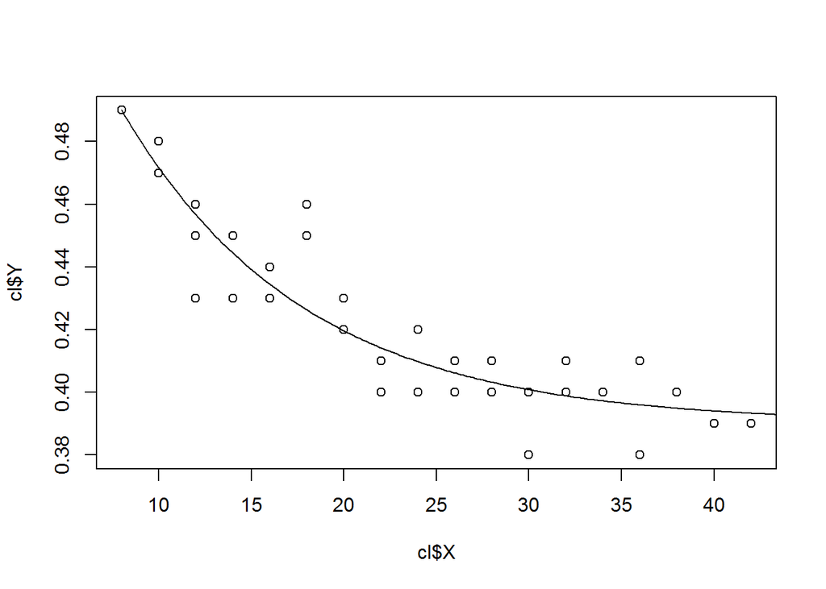

```r
#plot the fitted line and scatter plot
xfit<-seq(8,44,len=200)
yfit<-predict(nls.sol, data.frame(X=xfit))
plot(cl$X, cl$Y)
lines(xfit,yfit)
```